# In-Class Activities: Week 3

We’re going to do some individual and group activities about the *analysis* of data transfiguration tasks as well as their *design*. After constructing a design, and only after, you’re going to *implement* the design in R.

It’s important to have a goal and a plan for data table transfigurations. This need not be elaborate.

## Fashions in Naming

Objective: create a graph like the following.

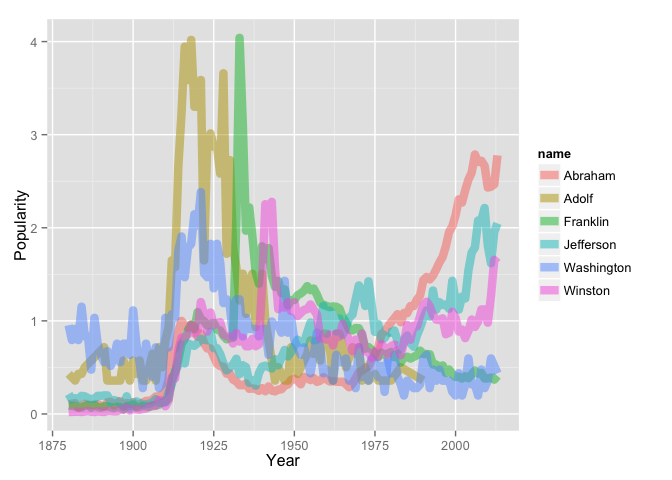

The raw material you have is the `BabyNames` data set in the DCF package. Write a few example lines in the format of the `BabyNames`, identifying the variable names and typical levels or values.

Point out which variables are categorical. These can potentially be used for defining groups of cases.

### First, Individually …

#### Step 1.

Analyze the graphic to figure out what a glyph-ready data table should look like. Mostly, this involves figuring out what variables are represented in the graph. Write down a small example of the glyph-ready data frame. and how they relate to the variable in the raw materials.

- What variable(s) from the raw data table do not appear at all in the graph?
- What variable(s) in the graph are similar to corresponding variables in the raw data table, but might have been transformed in some way.

#### Step 2

Consider how the cases differ between the raw input and the glyph-ready table. * Have cases been **filtered** out? * Have cases been grouped and **aggregated/summarized** within groups in any way? * Have any new variables been introduced?

#### Step 3

Using English, write down a sequence of steps that will accomplish the transfiguration from the raw data table to your hypothesized glyph-ready data table.

#### Step 4: Confer with your colleagues

As a group, compare your different analyses in Steps 1 through 3. Your goal is to develop a consensus for the design in Step 3.

But **FIRST**, each person in turn should present his or her analysis with others in the group **listening**. Don’t be shy about saying things like, “But I’m not sure about this,” or, “Hearing what person X just said, I realize that this is wrong. I’ll explain how it’s wrong.”

**AFTER** everyone has presented, start a discussion to develop a consensus about the sequence of operations and the parameters of each (e.g.: What’s being filtered out.) Use the whiteboard to keep a record of your consensus.

#### Step 5: First individually, then as a group.

Translate your design, step by step, into R.

#### Step 6: Implementation

Now you can start writing the commands themselves. Do so, try to identify and solve any problems that arise, and make your glyph-ready data.

For graphing, you can use this template:

```r
Results %>% ggplot(aes(x=year,y=total,group=name)) +
   geom_line( size=3, alpha=.5, aes(color=name)) +
   ylab("Popularity") + xlab("Year")
```

## Birds

Use the `OrdwayBirds` and `OrdwaySpeciesNames` data tables to * find the peak month for each major species * find major species that are seen in good numbers for at least 6 months of the year * identify, for the major species over each month, whether they tend to be seen almost only at the beginning or end of the month.

## Disasters

Case studies: Disasters. Which forms cause the most damage, greatest loss of life, economic loss.

- Rates in the country data, e.g. miles of road per area,
- Fraction alive, cardio, other in NHANES

### Filter

- Groupwise means and sd.
- Counts using group_by() and n(). (Group by the levels of the variable to be counted, perhaps including another variable for subdivisions.)
- Converting counts to proportions. (Divide by sum().)

  ```r
  mosaicData::KidsFeet %>% group_by( biggerfoot,sex ) %>%
  summarise(count=n() )
  ```

  ```
  Source: local data frame [4 x 3]
  Groups: biggerfoot

    biggerfoot sex count
  1          L   B    11
  2          L   G    11
  3          R   B     9
  4          R   G     8
  ```

- Graphics with mPlot(), mBar(), mMap()
- Add a layer to a map, perhaps zip-code population with state boundaries.
- Who votes for whom? Wade county voters: create cross tabs on registration, etc. Make bar charts to display patterns.

## Week 3

EXERCISE:

END OF EXERCISE.